# Erythranthe divergence

Thom Nelson

## Length of bait regions

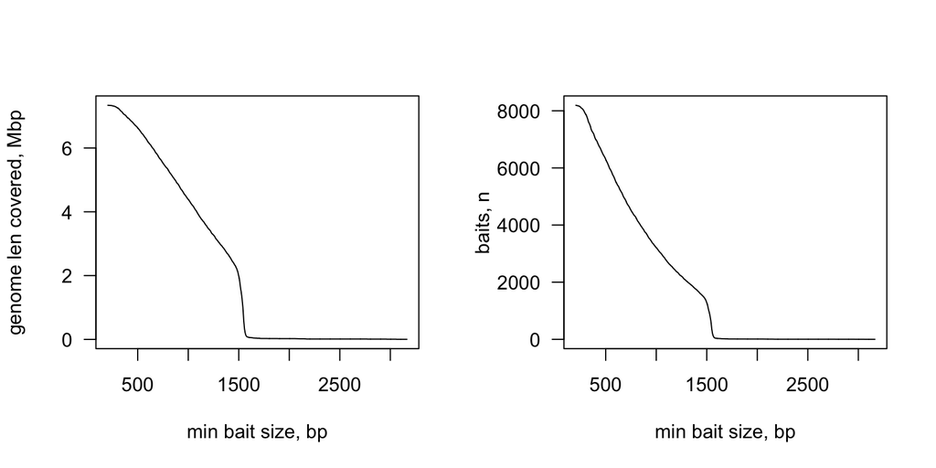

```r
covered <- sum(dxy$span)
minlen   <- min(dxy$span)
maxlen   <- max(dxy$span)
stepsize <- 1
sizes    <- seq(minlen,maxlen,stepsize)
lengths  <- NULL
nbaits   <- NULL
for (s in sizes) {
    lengths <- append(lengths, sum(dxy$span[dxy$span >= s]))
    nbaits  <- append(nbaits, length(dxy$span[dxy$span >= s]))
}

layout(matrix(1:2,1,2))
plot(sizes, lengths/1000000, type='l', las=1,
     xlab = "min bait size, bp",
     ylab = "genome len covered, Mbp")
plot(sizes, nbaits, type='l', las=1,
     xlab = "min bait size, bp",
     ylab = "baits, n")
```

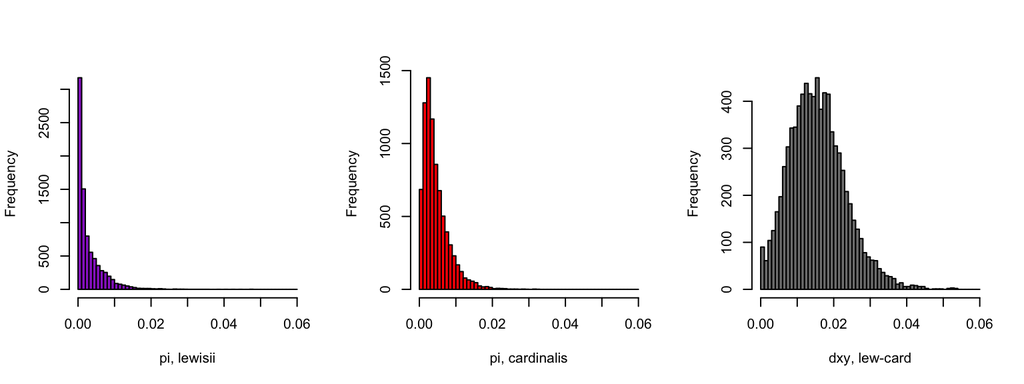

```r
layout(matrix(1:3,1,3))
hist(dxy$pi.slew, col=lewcol,main="",
     xlab = "pi, lewisii",
     xlim=c(0,0.06), breaks = seq(0,0.06,by=0.001))
hist(dxy$pi.ccar, col=cardcol,main="",
     xlab = "pi, cardinalis",
     xlim=c(0,0.06), breaks = seq(0,0.06,by=0.001))
hist(dxy$dxy.slew.ccar, col="gray50",main="",
     xlab = "dxy, lew-card",
     xlim=c(0,0.06), breaks = seq(0,0.06,by=0.001))
```

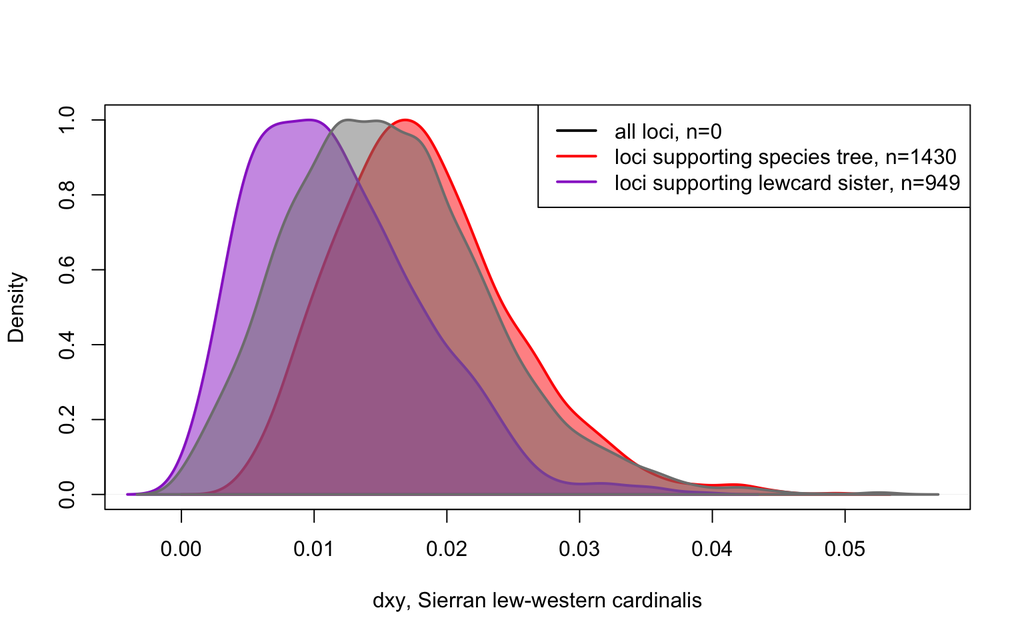

```r
loci <- intersect(sorting$region,dxy$region)
sorting <- sorting[sorting$region %in% loci,]
    sorting <- sorting[order(sorting$CHR,sorting$start),]
dxy     <- dxy[dxy$region %in% loci, ]
    dxy <- dxy[order(dxy$chr,dxy$start),]

species.index <- (sorting$CPVmono ==1 | sorting$CVmono == 1) & sorting$sLmono == 1
lewcard.index <- sorting$sLCPmono == 1 | sorting$sLCmono == 1 | sorting$LCmono == 1
CP.index      <- sorting$sLCPmono == 1 & sorting$sLmono == 1

dxy.in.species <- dxy$dxy.slew.ccar[species.index]
    sp.dens    <- density(dxy.in.species)
    sp.dens$y  <- sp.dens$y / max(sp.dens$y)
dxy.in.lewcard <- dxy$dxy.slew.ccar[lewcard.index]
    lc.dens    <- density(dxy.in.lewcard)
    lc.dens$y  <- lc.dens$y / max(lc.dens$y)
dxy.cp         <- dxy$dxy.slew.ccar[CP.index]
dxy.dens       <- density(dxy$dxy.slew.ccar)
    dxy.dens$y <- dxy.dens$y / max(dxy.dens$y)


plot(dxy.dens, type='n',lwd=2,main="",xlab="dxy, Sierran lew-western cardinalis")
    polygon(x = c(sp.dens$x,rev(         sp.dens$x)),
            y = c(sp.dens$y,rep(0,length(sp.dens$y))),
            col = adjustcolor(cardcol,alpha=0.5), border = cardcol,lwd=2)
    polygon(x = c(lc.dens$x,rev(         lc.dens$x)),
            y = c(lc.dens$y,rep(0,length(lc.dens$y))),
            col = adjustcolor(lewcol,alpha=0.5), border = lewcol,lwd=2)
    polygon(x = c(dxy.dens$x,rev(         dxy.dens$x)),
            y = c(dxy.dens$y,rep(0,length(dxy.dens$y))),
            col = adjustcolor("gray50",alpha=0.5), border = "gray50",lwd=2)
    # lines(sp.dens, lwd=2,col=cardcol)
    # lines(lc.dens, lwd=2,col=lewcol)
    legend(x="topright", lwd=2, col=c("black",cardcol,lewcol),
           legend=c(paste0("all loci, n=",length(dxy$dxy.slewccar)),
                    paste0("loci supporting species tree, n=",length(dxy.in.species)),
                    paste0("loci supporting lewcard sister, n=",length(dxy.in.lewcard))))
```

### lew-card introgression, or massive card-verb introgression?

We hypothesized that the discordance between our inferred species tree and the molecular phylogeny of Beardsley et al is due to more recent introgression between *lewisii* and *cardinalis*. However, it may be the case that the placement here of *cardinalis* sister to the other hummingbird-pollinated species is due to massive introgression from that clade into *cardinalis*.

We tested these two possibilities by examining sequence divergence between putative sister taxa at genes whose genealogies support that sister relationship. Introgression will result in more recent shared ancestry between *cardinalis* and the donor species than between *cardinalis* and its true sister species. Therefore, if the placement of cardinalis sister to the HP clade is due to massive introgression, sequence divergence between *cardinalis* and a HP species in genomic regions supporting the introgression topology [((CARD,VERB),LEW)] will be lower than divergence between *cardinalis* and *lewisii* in regions supporting the species tree from Beardsley et al [((CARD,LEW),VERB)]. However, the inverse will be true if the ML topology we inferred here represents the true species history.

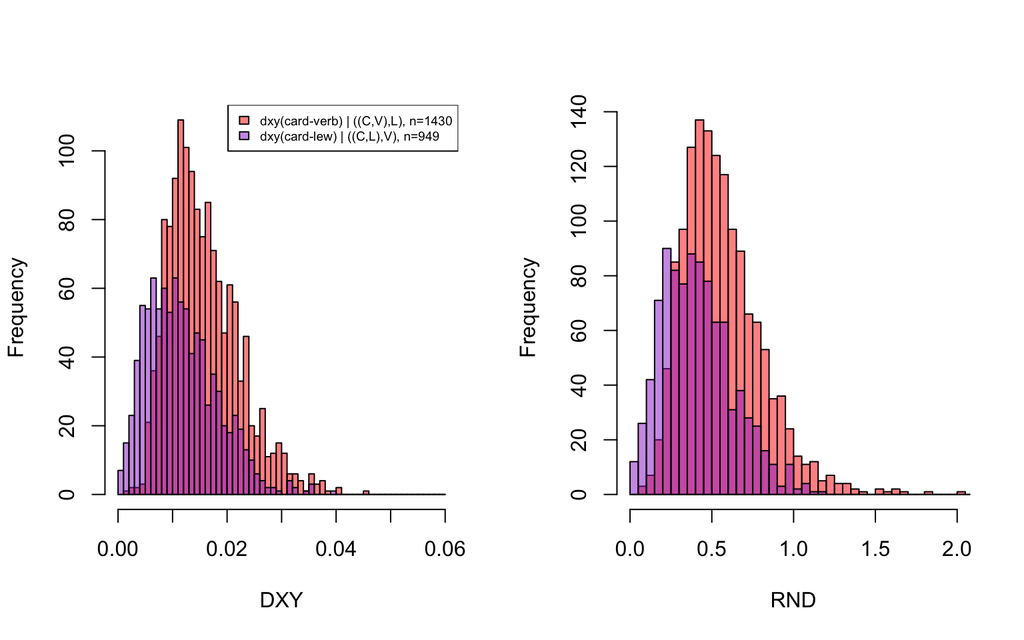

```r
species.index <- (sorting$CPVmono ==1 | sorting$CVmono == 1) & sorting$sLmono == 1
lewcard.index <- sorting$sLCPmono == 1 | sorting$sLCmono == 1 | sorting$LCmono == 1
CP.index      <- sorting$sLCPmono == 1 & sorting$sLmono == 1

CVgivenSpecies <- dxy$dxy.ccar.verb[species.index]
CVgivenSpecies.RND <- dxy$dxy.ccar.verb[species.index] /
                     dxy$dxy.CV.bic[species.index]
CLgivenBeardsley <- dxy$dxy.slew.ccar[lewcard.index]
CLgivenBeardsley.RND <- dxy$dxy.slew.ccar[lewcard.index] /
                      dxy$dxy.sLC.bic[lewcard.index]

breaks.RND <- seq(0,4,by=0.05)
breaks     <- seq(0,0.06,by=0.001)

layout(matrix(1:2,1,2,byrow=T))
hist(CVgivenSpecies, breaks = breaks,
     main="",xlab="DXY",col=adjustcolor(cardcol,alpha=0.5))
    hist(CLgivenBeardsley, breaks = breaks,add=T,
         col=adjustcolor(lewcol,alpha=0.5))
    legend(x="topright", cex=0.6,
           fill=adjustcolor(c(cardcol,lewcol),alpha=0.5),
           legend=c(
                    paste0("dxy(card-verb) | ((C,V),L), n=",
                           length(dxy.in.species)),
                    paste0("dxy(card-lew) | ((C,L),V), n=",
                           length(dxy.in.lewcard))))
hist(CVgivenSpecies.RND, breaks = breaks.RND, xlim = c(0,2),
     main="",xlab="RND",col=adjustcolor(cardcol,alpha=0.5))
    hist(CLgivenBeardsley.RND, breaks = breaks.RND,add=T,
         col=adjustcolor(lewcol,alpha=0.5))
```

Levels of sequence divergence from *cardinalis* indicate that sistership with *lewisii* is due to introgression between *cardinalis* and *lewisii*. d<sub>XY</sub><sup>*LC*</sup> in genomic regions supporting a *lewisii-cardinalis* sister relationship is generally lower than d<sub>XY</sub><sup>*CV*</sup> in genomic regions supporting the ML topology.

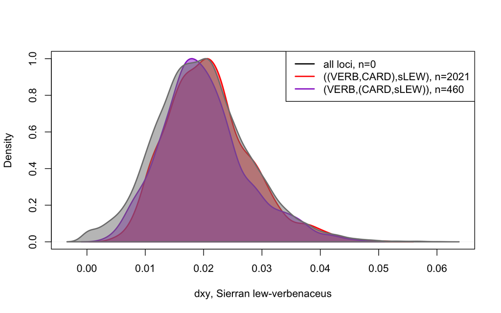

```r
loci <- intersect(sorting$region,dxy$region)
sorting <- sorting[sorting$region %in% loci,]
    sorting <- sorting[order(sorting$CHR,sorting$start),]
dxy     <- dxy[dxy$region %in% loci, ]
    dxy <- dxy[order(dxy$chr,dxy$start),]

treeAB.index <- sorting$CPVmono  == 1 | sorting$CVmono  == 1
treeBC.index <- sorting$sLCPmono == 1 | sorting$sLCmono == 1



dxy.sLverb.AB <- dxy$dxy.slew.verb[treeAB.index]
    AB.dens    <- density(dxy.sLverb.AB)
    AB.dens$y  <- AB.dens$y / max(AB.dens$y)
dxy.sLverb.BC <- dxy$dxy.slew.verb[treeBC.index]
    BC.dens    <- density(dxy.sLverb.BC)
    BC.dens$y  <- BC.dens$y / max(BC.dens$y)
dxy.dens       <- density(dxy$dxy.slew.verb)
    dxy.dens$y <- dxy.dens$y / max(dxy.dens$y)


plot(dxy.dens, type='n',lwd=2,main="",xlab="dxy, Sierran lew-verbenaceus")
    polygon(x = c(AB.dens$x,rev(         AB.dens$x)),
            y = c(AB.dens$y,rep(0,length(AB.dens$y))),
            col = adjustcolor(cardcol,alpha=0.5), border = cardcol,lwd=2)
    polygon(x = c(BC.dens$x,rev(         BC.dens$x)),
            y = c(BC.dens$y,rep(0,length(BC.dens$y))),
            col = adjustcolor(lewcol,alpha=0.5), border = lewcol,lwd=2)
    polygon(x = c(dxy.dens$x,rev(         dxy.dens$x)),
            y = c(dxy.dens$y,rep(0,length(dxy.dens$y))),
            col = adjustcolor("gray50",alpha=0.5), border = "gray50",lwd=2)
    # lines(sp.dens, lwd=2,col=cardcol)
    # lines(lc.dens, lwd=2,col=lewcol)
    legend(x="topright", lwd=2, col=c("black",cardcol,lewcol),
           legend=c(paste0("all loci, n=",length(dxy$dxy.slewverb)),
                    paste0("((VERB,CARD),sLEW), n=",length(dxy.sLverb.AB)),
                    paste0("(VERB,(CARD,sLEW)), n=",length(dxy.sLverb.BC))))
```

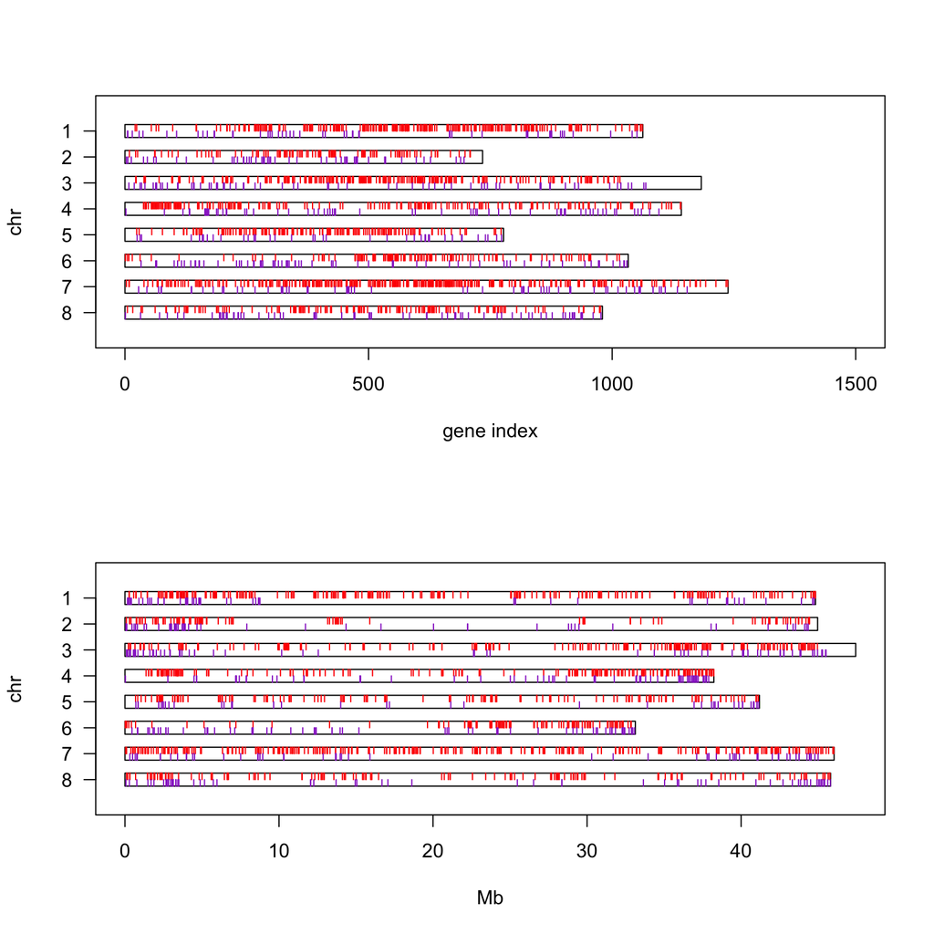

```r
### RELATIVE DISTRIBUTION OF TREE TOPOLOGIES ON CHROMOSOMES

linelen <- 0.25
lwd     <- 1
lalpha  <- 0.25

layout(matrix(1:2, 2,1,byrow=T))
plot(c(0,1500),c(-9,0),type="n",yaxt='n',ylab="chr",xlab="gene index")
    axis(2, at = -1:-8,labels=1:8,las=1)
    for (c in 1:8) {
        chrsort <- sorting[sorting$CHR == c,]
        chrsort$index <- 1:length(chrsort$CHR)
        rect(xleft=0,xright=max(chrsort$index),
             ybottom=(-1*c)-linelen,ytop=(-1*c)+linelen)
        sp <- chrsort$index[(chrsort$CPVmono ==1 | chrsort$CVmono == 1) &
                                chrsort$sLmono == 1]
        lc <- chrsort$index[chrsort$sLCPmono == 1 | chrsort$sLCmono == 1]
        cp <- chrsort$index[chrsort$sLCPmono == 1 & chrsort$sLmono == 1]
        segments(x0 = sp, x1 = sp, y0 = (-1*c), y1 = (-1*c)+linelen,col=cardcol)
        segments(x0 = lc, x1 = lc, y0 = (-1*c), y1 = (-1*c)-linelen,col=lewcol)
    }
plot(c(0,max(sorting$stop)/1000000),c(-9,0),type="n",yaxt='n',ylab="chr",xlab="Mb")
    axis(2, at = -1:-8,labels=1:8,las=1)
    for (c in 1:8) {
        chrsort <- sorting[sorting$CHR == c,]
        chrsort$index <- 1:length(chrsort$CHR)
        rect(xleft=0,xright=max(chrsort$stop)/1000000,
             ybottom=(-1*c)-linelen,ytop=(-1*c)+linelen)
        sp <- chrsort$start[(chrsort$CPVmono ==1 | chrsort$CVmono == 1) &
                                chrsort$sLmono == 1]/1000000
        lc <- chrsort$start[chrsort$sLCPmono == 1 | chrsort$sLCmono == 1]/1000000
        cp <- chrsort$start[chrsort$sLCPmono == 1 & chrsort$sLmono == 1]/1000000
        segments(x0 = sp, x1 = sp, y0 = (-1*c), y1 = (-1*c)+linelen,col=cardcol)
        segments(x0 = lc, x1 = lc, y0 = (-1*c), y1 = (-1*c)-linelen,col=lewcol)
    }
```